# Tarea 1

José López Joel Patricio

## Problema 1

Las propiedades de las funciones de riesgo: Supongamos que una variable aleatoria de supervivencia $T$ con una densidad una mezcla de dos exponenciales.

$$f_{t}=p\lambda^{-\lambda t}+(1-p)\mu
e^{-\mu t}; t \geq0$$

donde $0<p<1$ es el parámetro de proporción de la mezcla $0<\lambda<\mu<1$ son parametros de cada exponencial en la mezcla.

### a).

Encuentre la función de supervivencia $S(t)$

La función de riesgo es:

$$S(t)=\int_{t}^{\infty}p\lambda
e^{-\lambda t}+(1-p)\mu e^{-\mu t}dt$$
$$=p\lambda\int_{t}^{\infty}e^{-\lambda
t}dt+(1-p)\mu\int_{t}^{\infty}e^{-\mu t}dt$$
$$=-pe^{-\lambda t}|_{t}^{\infty}-(1-p)e^{-\mu
t}|_{t}^{\infty}$$
$$=pe^{t}+(1-p)e^{-\mu t}$$

### b).

Encuentre la función de riesgo $h(t)$ para $T$ y explique anliticamente o intituvamente por que es decreciente en función de su argumento positivo $t$.

$$\lim_{n \to \infty}=\lim_{n \to
\infty}\frac{f_{T}(t)}{S(t)}=\lim_{n \to \infty}\left(\frac{p\lambda
e^{-\lambda t}+(1-p)\mu e^{-\mu t}}{1-[p(1- e^{-\lambda
t})+(1-p)(1-e^{-\mu t})]}\right)$$

## Problema 2

Sea la variable aleatoria $T=e^y$ que representa el tiempo de supervivencia con distribución en la familia log-localidad-escala.

$$P(Y\geq
y)=S_{0}\left(\frac{y-\mu}{\sigma} \right)$$

### a)

Derive la función de densidad de probabilidades de $T$ bajo es supuesto que $S_{0}(\mu)=1-\Phi(\mu),$ donde $\Phi(\mu)$ es la funcion de distribución de una $N(0,1)$

$$P(Y\geq
y)=S_{0}\left(\frac{y-\mu}{\sigma} \right)$$

$$p(Y\leq
y)=1-S_{0}\left(\frac{y-\mu}{\sigma} \right)$$

Ahora:

$$p(Y\leq y)=1- \left(1-\Phi
\left(\frac{y-\mu}{\sigma} \right)\right)$$
$$=\Phi \left(\frac{y-\mu}{\sigma} \right)$$
Tenemos que: T=e^{y} tiene una distribución localidad-escala. $\Phi\sim N(0,1)$

$$F_{T}(t)=P \left ( U\leq
\left(\frac{log(t)-\mu}{\sigma} \right)\right)$$

$$=\Phi \left(\frac{log(t)-\mu}{\sigma}
\right)$$

$$f_{t}=\frac{d}{dt} \Phi
\left(\frac{log(t)-\mu}{\sigma} \right)$$

$$=\Phi\left(\frac{log(t)-\mu}{\sigma}
\right)\left( \frac{1}{\sigma t}\right)$$

$$\therefore~ T\sim
lognormal(\mu,\sigma)$$

### b).

Derive la función de densidad de probabilidades de $T$ bajo el supuesto que $S_{0}(\mu)=-e^{\mu},$ use $\alpha=e^{\mu}$ y $\beta=\frac{1}{\sigma}$

$$P(Y\geq
y)=S_{0}\left(\frac{y-\mu}{\sigma} \right)$$

$$P(Y\leq
y)=1-S_{0}\left(\frac{y-\mu}{\sigma} \right)$$

$$=1-exp\left({-e^{\left(\frac{log(t)-\mu}{\sigma}
\right)}}\right)$$

Derivando:

$$=f_{Y}(y)=\frac{d}{dt}\left(
1-exp\left({-e^{\left(\frac{log(t)-\mu}{\sigma} \right)}}\right)
\right)$$

$$=\frac{1}{\sigma
t}exp\left(\frac{log(t)-\mu}{\sigma} -e^{\left(\frac{log(t)-\mu}{\sigma}
\right)}\right)$$

$$\therefore~ T\sim
Weibull(\alpha,\beta)$$

## Problema 3

Sea T una variable aleatoria de tiempo de vida, con una función de riesgo en forma de bañera, tiene una distribución exponencial de potencia con función de supervivencia.

$$S(t)=e^{1-e^{(\lambda
t)^{\alpha}}}$$
### a).

Si $\alpha=0.5$ demuestre que la función de riesgo tiene forma de bañera y encuentre el tiempo en que la tasa de riesgo cambia de decreciente a creciente.

$$h(t)=\frac{\partial}{\partial
t}logS(t)$$

$$=\frac{e^{(\lambda
t)^{1/2}}\lambda^{2}}{2t^{1/2}}$$

Muestramos la grafica:

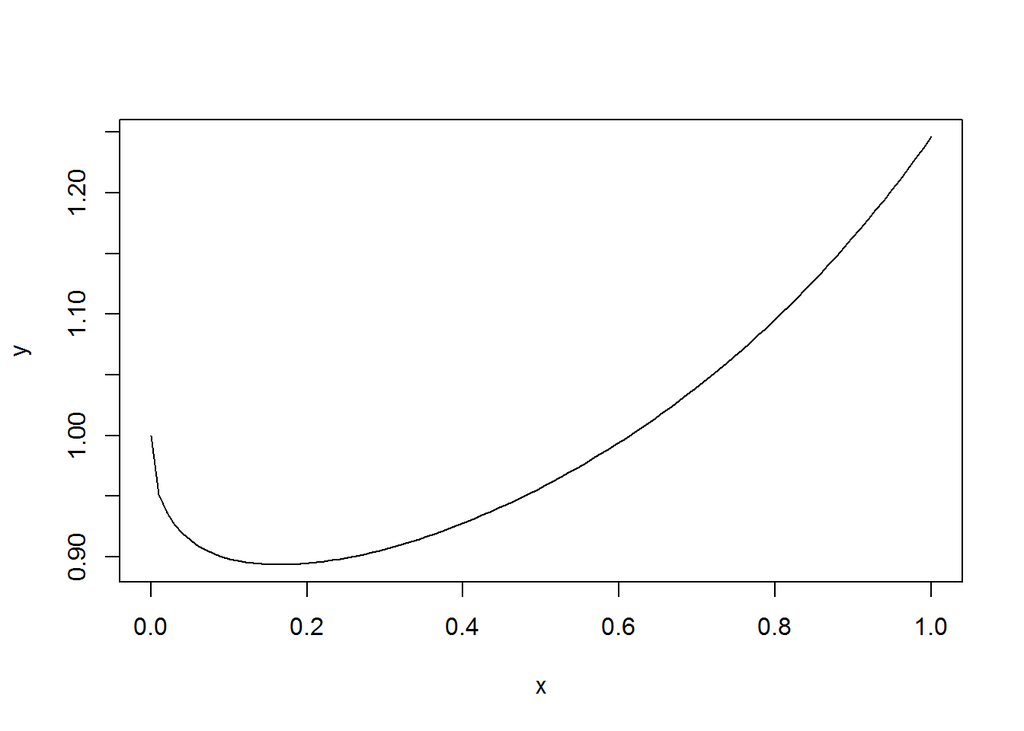

```r
lamb<-0.33
alfa<-0.5

d<-function(t)
  exp(1-exp((lamb*t)^alfa))


s<-function(t)
  d(t)/(1-integrate(d,0,t)$value)

x<-seq(0,1,length.out=100);
y<-apply(matrix(x),1,s)
plot(x,y,t="l")
```

```r
# PUNTO CRITICO

x[order(y)[1]]
```

```
## [1] 0.1616162
```

### b).

Si $alpha=2,$ demuestre que la tasa de riesgo de T es monótina y creciente.

*De forma análitica:*

$$h(t)=\frac{\partial}{\partial
t}logS(t)$$

$$h(t)=\frac{\partial}{\partial
t}1-1-e^{(\lambda t)^{2}}$$
$$=2\lambda^2te^{(\lambda t)^{2}}$$

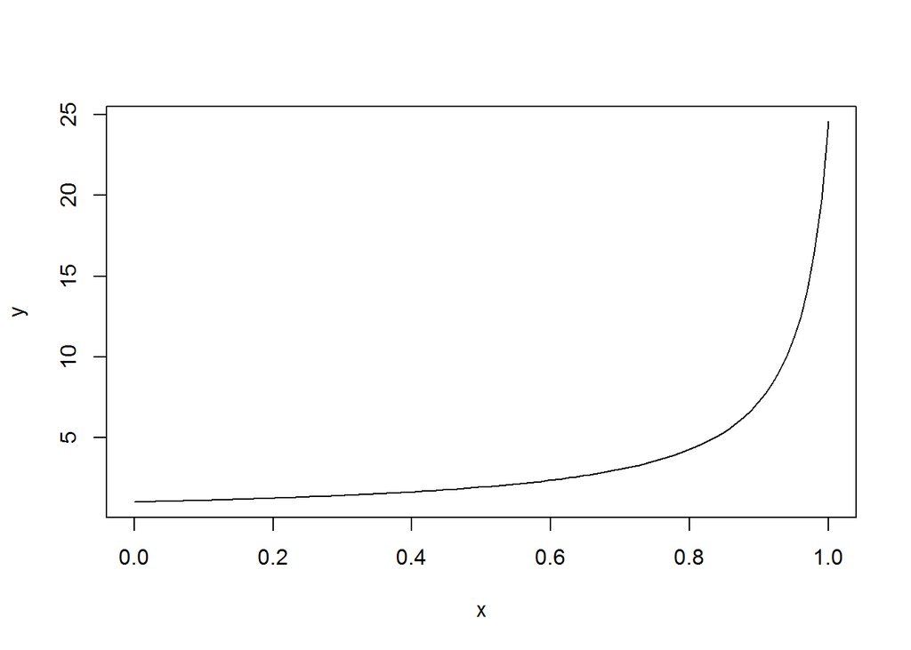

```r
lamb<-0.33
alfa<-2

d<-function(t)
  exp(1-exp((lamb*t)^alfa))


s<-function(t)
  d(t)/(1-integrate(d,0,t)$value)

x<-seq(0,1,length.out=100);
y<-apply(matrix(x),1,s)
plot(x,y,t="l")
```

```r
# PUNTO CRITICO

x[order(y)[1]]
```

```
## [1] 0
```

## Problema 4

Un modelo utilizando en la construcción de tablas de vida es de tasa de riesgo constante por partes. Aquí el eje de tiempo se divide en $k$ intervalos, $[\tau_{i-1},\tau_{i}),$ $i=1,...,k$ con $\tau_0=0$ y $\tau_{k}=\infty.$ La tasa de riesgo en el i-ésimo intervalo es un avalor constante, $\theta_i$ eso es:

$$h(t)=\left\lbrace\begin{array}{c}
\theta_1 ~ ~ 0\leq t<\tau_{1}\\ \theta_2 ~ ~ \tau_1\leq
t<\tau_{2}\\.\\.\\.\\\theta_{k-1} ~ ~ \tau_{k-2}\leq
t<\tau_{k-1}\\ \theta_k ~ ~ \tau_{k-1}\leq
t \end{array}\right.$$

### a)

Obtenga la función de supervivencia.

La función de supervicencia

$$S(t)=e^{-H(t)}\\donde:\\H(t)=\int_{0}^{t}h(u)du$$

Realizando los calculos tenemos:

*Función de riesgo acumulado*

$$H(t)=\left\lbrace\begin{array}{c}
\theta_{1}t~~~~~~~~~~~~~~~~~~~~~~~~~~~~~~~~~~~~~~~~~~~ ~ ~~~~~~~ ~
~~~~~~~ ~ ~ 0\leq t<\tau_{1}\\ \theta_{i}\tau_{1}+\theta_2(t-\tau_1)
~~~~~~ ~~~~~~~~~~~~~~~~~~~~~~~~~~~~~~~ ~ \tau_1\leq
t<\tau_{2}\\.\\.\\.\\\theta_{1}\tau_{1}+...+\theta_{k-2}\tau_{k-2}+\theta_{k-1}(t-\tau_{k-2})~~~~~~~~~~~~~~~~~~
~ ~ \tau_{k-2}\leq t<\tau_{k-1}\\
\theta_{1}\tau_{1}+...+\theta_{k-1}\tau_{k-1}+\theta_{k}(t-\tau_{k-1}) ~
~~~~~~~~~~~~~~~~~~~~~~ \tau_{k-1}\leq t \end{array}\right.$$

*La funcion de supervicencia es:*

$$S(t)=\left\lbrace\begin{array}{c}
e^{-\theta_{1}t}~~~~~~~~~~~~~~~~~~~~~~~~~~~~~~~~~~~~~~~~~~~ ~ ~~~~~~~ ~
~~~~~~~ ~ ~ 0\leq t<\tau_{1}\\ e^{-(\theta_1
\tau_1+\theta_2(t-\tau_1))} ~~~~~~ ~~~~~~~~~~~~~~~~~~~~~~~~~~~~~~~ ~
\tau_1\leq t<\tau_{2}\\.\\.\\.\\ e^{-(\theta_1
\tau_{1}+...+\theta_{k-2}\tau_{k-2}+\theta_{k-1}(t-\tau_{k-2}))}~~~~~~~~~~~~~~~~~~
~ ~ \tau_{k-2}\leq t<\tau_{k-1}\\ e^{-(\theta_1
\tau_{1}+...+\theta_{k-1}\tau_{k-1}+\theta_{k}(t-\tau_{k-1}))} ~
~~~~~~~~~~~~~~~~~~~~~~ \tau_{k-1}\leq t \end{array}\right.$$

### b)

Encuentre la función de vida residual media.

$$S(t)=\left\lbrace\begin{array}{c}
\frac{1}{\theta_{1}}~~~~~~~~~~~~~ ~ ~~~~~~~ ~ ~~~~~~~ ~ ~ 0\leq
t<\tau_{1}\\ \frac{1}{\theta_{2}} ~~~~~~~~~~~~~~~~~~~~~~~~~~~~~ ~
\tau_1\leq t<\tau_{2}\\.\\.\\.\\
\frac{1}{\theta_{k-1}}~~~~~~~~~~~~~~~~~~~~ ~ ~ \tau_{k-2}\leq
t<\tau_{k-1}\\ \frac{1}{\theta_{k}} ~ ~~~~~~~~~~~~~~~~~~~~~~~~~~~~~~~
\tau_{k-1}\leq t \end{array}\right.$$

## Problema 5

En algunas aplicaciones, se incluye parametro, llamado tiempo de arantia. Este parámetro $\phi$ es el tiempo más pequeño en que podría ocurrir una falla. Considere que en la variable aleatoria tiempo de vda $T$ tiene una función de supervivencia $Weibull$ de tres parámetros de distrubución está dada por:

$$S(t)=\left\lbrace\begin{array}{c}
e^{-\lambda(t-\phi)^{\alpha}}~~~~~~~~~~
~~~ si~ ~~~~~~~ ~ ~~~~~~~ ~ ~ t\geq \phi\\
1~~~~~~~~~~~~~~~~~~~~~si~~~~~~~~~~~~~~~~~~~~~t<0 \end{array}\right.$$

### a).

Encuentre la función de riesgo y la función de densidad de la distribucion $Weibull$ de tres parámetros.

$$h(t)=\frac{\partial}{\partial
t}log(S(t))$$
Aplicamos las derivadas parciales tenemos:

$$h(t)=\left\lbrace\begin{array}{c}
\frac{\partial}{\partial
t}log\left(e^{-\lambda(t-\phi)^{\alpha}}\right)~~~~~~~~~~~~~ si~ ~~~~~~~
~ ~~~~~~~ ~ ~ t\geq \phi\\ \frac{\partial}{\partial
t}log(1)~~~~~~~~~~~~~~~~~~~~~si~~~~~~~~~~~~~~~~~~~~~t<0 \end{array}\right.$$

$$h(t)=\left\lbrace\begin{array}{c}
\alpha\lambda(t-\phi)^{\alpha-1}~~~~~~~~~~~~~ si~ ~~~~~~~ ~ ~~~~~~~ ~ ~
t\geq \phi\\
0~~~~~~~~~~~~~~~~~~~~~si~~~~~~~~~~~~~~~~~~~~~t<0 \end{array}\right.$$

$$f(t)=h(t)S(t)$$

Finalmente tenemos:

$$f(t)=\alpha\lambda(t-\phi)^{\alpha-1}e^{-\lambda(t-\phi)^{\alpha}}$$

### b).

Suponga que el tiempo de supervivencia T sigue una distribución Weibull de tres parámetros con $\alpha = 1,$ $\lambda= 0.0075$ y $\phi = 100.$ Encuentra la media y la mediana de los tiempos de vida.

Tenemos para la *media*

$$f_{T}(t)=0.0075e^{0.0075(t-100)};~~~~~~100\leq
t<\infty$$

$$E(T)=\int_{100}^{\infty}t~
0.0075e^{0.0075(t-100)}dt$$
$$=0.0075e^{0.75}\int_{100}^{\infty}t~e^{0.0075t}dt$$
*Media*

$$S(m)=100-e^{-0.0075(m-100}$$
Resolviendo en R tenemos:

```r
alfa<-1
lamda<-0.0075
fi=100
condicion<-expression(exp(-lamda*(t-fi)^alfa))

f<-function(t)
  if(t>=fi)-1*eval(deriv(condicion,'t')) else 0

h<-function(t)
  func(t)/eval(condicion)
```

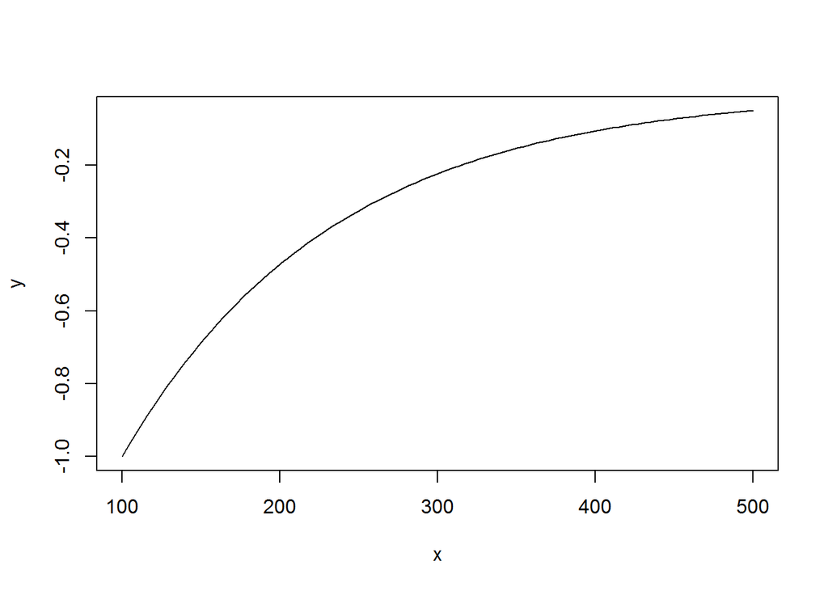

```r
x<-matrix(seq(100,500,length.out=100))
y<-apply(x,1,f)
plot(x,y,t='l')
```

```r
# media

media<-(t(x)%*%y)/sum(y)
media
```

```
##          [,1]
## [1,] 210.8173
```

```r
# mediana

Z<-y/sum(y)
J<-1
M<-Z[J]
while (M<.5) {
  J<-J+1
  M<-M+Z[J]
}

Mediana<-x[J]
Mediana
```

```
## [1] 184.8485
```

### Problema 6

Sea $T$ una variable aleatoria de tiempo de vida con distribución $weibull$ de dos parametros, con función de supervivencia

$$S(t)=e^{-\lambda t^\alpha}$$

Suponga que tenemos una muestra aleatoria, derive la función de verosimiltud para los siguentes casos:

### a).

Tenemos una m.a, de datos *truncados* por la izquierda $(y_{li},t_i)$, sujetos a $y_{li}≤ t_i; i = 1, 2, ..., n$ donde $y_{li}$ son tiempos de truncamiento por la izquierda.$(tip: L_i= P (T = t_i|T ≥ y_{li}))$

$$L(\alpha,\beta;t)=\prod_{1}^{n}P(T=t_i|t\geq
y_{li})$$

$$=\prod_{1}^{n}\frac{f(t_i)}{P(T\geq
y_{li})}$$

$$=\prod_{1}^{n}\frac{\alpha\lambda
t^{\alpha-1}e^{-\lambda}t^{\alpha}_{i}}{e^{-\lambda
y_{li}^{\alpha}}}$$

### b).

Tenemos una m.a, de datos censurados por intervalo $(Li, Ri); i = 1, ..., n.$ $(tip: Li = P (Li ≤ Ti ≤ Ri))$

$$L(\alpha,\beta;t)=\prod_{i}^{n}P(l_{li}\leq T
\geq r_{i})$$

$$=\prod_{i}^{n}(F(r_i)-F(l_i))=\prod_{i}^{n}\left(-e^{-\lambda
r^{\alpha}_{i}}+e^{-\lambda l_{i}^{\alpha}} \right)$$

$$=\prod_{i}^{n}\left(e^{-\lambda
l_{i}^{\alpha}}-e^{-\lambda r_{i}^{\alpha}} \right)$$

### c)

Datos con truncamiento doble $(yli, ti, yri),$ sujetos a $yli≤ ti ≤ yri ; i = 1, 2, ..., n.$ $(tip: Li = P (T =ti|Li ≤ Ti ≤ Ri))$

Truncamiento doble:

$$f(y|a<y<b)=\frac{f(y)}{P(a<Y<b)}$$

$$L(\lambda,\alpha;t)=\prod_{1}^{n}P(T=t|y_{li}<T<yr_i$$

$$=\prod_{1}^{n}\frac{f(t)}{P(y_{li}<T<y_{ri})}$$

$$=\prod_{1}^{n}\frac{f(t_i)}{P(y_{li}<T\geq
y_{ri})}$$

$$=\prod_{1}^{n}\frac{f(t_i)}{F(y_{ri})-F(
y_{li})}$$

$$=\prod_{1}^{n}\frac{\lambda
\alpha(\lambda t)^{\alpha-1}e^{-(\lambda t_{i})^\alpha}}{e^{-(\lambda
yt_{i})^{\alpha}}+e^{-(\lambda y_{ri})^{\alpha}}}$$

$$=(\lambda \alpha)^{n}
\prod_{1}^{n}\frac{(t)^{\alpha-1}e^{-(\lambda
t_{i})^\alpha}}{e^{-(\lambda yt_{i})^{\alpha}}+e^{-(\lambda
y_{ri})^{\alpha}}}$$

### d).

caso censura por intervalo y truncamiento).Considere la un muestra de cuatro pacientes cuya edad al moneto de su muerte estaba en lso intervalos $(90, 120], (110, 15], (80, 100], (70, 75])$ sujeto a que la condición de entrada es de 90 años o mas. $(tip: Li = P (Li ≤ Ti ≤ Ri|T ≥ yli))$

La verosimilitud se expresa como:

$$L(\lambda,\alpha;t)=\prod_{i=1}^{n}\frac{P(l_i<T<R_i)}{P(T>y_{li})}$$

$$=\frac{P(90<T\leq120)}{P(T
\geq90)}\frac{P(110<T\leq115)}{P(T
\geq90)}\frac{P(80<T\leq100)}{P(T \geq90)}\frac{P(70<T\leq75)}{P(T
\geq90)}$$
$$=\frac{e^{-\lambda120^\alpha}+e^{-\lambda90^\alpha}}{e^{-\lambda90^\alpha}}\frac{e^{-\lambda115^\alpha}+e^{-\lambda110^\alpha}}{e^{-\lambda90^\alpha}}\frac{e^{-\lambda100^\alpha}+e^{-\lambda80^\alpha}}{e^{-\lambda90^\alpha}}\frac{e^{-\lambda75^\alpha}+e^{-\lambda70^\alpha}}{e^{-\lambda90^\alpha}}$$

$$=\left(\frac{1}{e^{-\lambda90^\alpha}}\right)^4(e^{-\lambda120\alpha}+e^{-\lambda90\alpha})(e^{-\lambda115\alpha}+e^{-\lambda110\alpha})(e^{-\lambda100\alpha}+e^{-\lambda80\alpha})(e^{-\lambda75\alpha}+e^{-\lambda70\alpha})$$

## Problema 7

Sea $Y_1, Y_2, ..., Y_n$ variables aleatorias continuas e independientes de supervivencia y sea Y una nueva variable aleatoria de supervivencia, definida $W = min(Y_1, Y_2, ..., Y_n)$ Si $Y_i$ tiene función de supervivencia $SYi(y) =exp(−α_iyβ)$ para $αi > 0, y > 0,$ determine la función de riesgo para $n^{1/β}W.$

Distribuciión $Weibull $

$$W\sim Weibull
\left(\sum_{i=1}^{n}\alpha_i,\beta\right)$$

Sea

$$Y=n^{\frac{1}{\beta}}W$$

$$F_{Y}(y)=P(Y<y)=P(n^{\frac{1}{\beta}}W<y)=P(W<y/n^{\frac{1}{\beta}})$$

$$=1-e^{-\sum_{i=1}^{n}\alpha_{i}(y/n^{\frac{1}{\beta}})^\beta}$$

$$=1-e^{-\frac{n}{n}\alpha
y^{\beta}}$$
$$1-e^{-\alpha
y^{\beta}}$$
Entonces:

$$W \sim
Weibull(\alpha,\beta)$$

## Problema 8

Considere los datos los datos del problema 8

Suponga las concentraciones se distribuyen lognormales $(µ,σ)$ construya la verosimilitud y obtenga los estimadores de m´axima verosimilitud, asi como sus varianzas estimadas.

Función de verosimilitud

$$L(\mu,\sigma^2;t)=\prod_{i=1}^{n}f(\mu_i,\mu,\sigma^2)^{\delta_{i}}F(\mu_i,\mu,\sigma^2)^{1-\delta_{i}}$$

```r
delta <-rep(.01,16)
datos  <-c(rep(.01,12),rep(.02,14),rep(.03,7),rep(.04,6),rep(.05,3),rep(.06,.47))


likehood<-function(theta)
{
  mu<-theta[1]; sigma<-theta[2]
-(sum(plnorm(delta,mu,sigma,log.p =TRUE))+
sum(dlnorm(datos,mu,sigma,log =TRUE)))

}
#Estimados


res<-optim(c(0,1),likehood,hessian =TRUE)
cbind(res$par,diag(solve(res$hessian))^.5)
```

```
##            [,1]       [,2]
## [1,] -4.2044716 0.10106231
## [2,]  0.7278615 0.08441115
```